# FAMD with heart attack dataset

Oumar Kane

14/04/2022

# Factorial Analysis of Mixed Data with the heart attack dataset

In this part of the project we have to diminish the number of variables with a another very used technic in data science which is the Factorial Analysis of Mixed Data (FAMD). We use the FAMD instead of PCA (Principal Component Analysis), because, as we saw in the previous part, we have not only quantitative variables in our dataset, we have also qualitative variables. So let’s begin.

## First steps

**Import the dataset, further** :

```r
heart_data_original = read.csv("E:/Oumar/Ordinateur Dell/oumar/documents/Cours/IA data forest/master semestre 2/Analyse de données/Projets/Data/Heart_disease/data/heart2.csv")

# Let's copy the dataset to do not lose it
heart_data = data.frame(heart_data_original)
```

We can go directly to the main steps because we had already explore the dataset.

**Correlated variables:** We saw that many variables are correlated together. We identified correlations between :

- The age variable and the other quantitative variables;
- oldpeak, trestbps and thalach
- chol and trestbps.

**Identify categorical variables:** We must change the type of the target to factor at first.

```r
for (i in c(2, 3, 6, 7, 9, 11, 12, 13, 14)){
  heart_data[, i] = as.factor(heart_data[, i])
}
```

**Test the logistic regression on the dataset:** We use a logistic regression model because the target `target` is a binary categorical variable.

```r
summary(glm(target~., data = heart_data, family = binomial))
```

```
##
## Call:
## glm(formula = target ~ ., family = binomial, data = heart_data)
##
## Deviance Residuals:
##     Min       1Q   Median       3Q      Max
## -2.8582  -0.2917   0.0718   0.4167   3.1908
##
## Coefficients:
##              Estimate Std. Error z value Pr(>|z|)
## (Intercept) -0.081901   2.028691  -0.040 0.967797
## age          0.026846   0.013950   1.924 0.054297 .
## sex1        -1.992347   0.314204  -6.341 2.28e-10 ***
## cp1          0.886380   0.308803   2.870 0.004100 **
## cp2          2.006394   0.286281   7.008 2.41e-12 ***
## cp3          2.409722   0.391965   6.148 7.86e-10 ***
## trestbps    -0.024979   0.006537  -3.821 0.000133 ***
## chol        -0.005462   0.002307  -2.367 0.017914 *
## fbs1         0.380096   0.319620   1.189 0.234356
## restecg1     0.397268   0.217975   1.823 0.068374 .
## restecg2    -0.800417   1.536998  -0.521 0.602530
## thalach      0.021692   0.006525   3.324 0.000886 ***
## exang1      -0.750331   0.248746  -3.016 0.002557 **
## oldpeak     -0.403411   0.132156  -3.053 0.002269 **
## slope1      -0.595618   0.472076  -1.262 0.207057
## slope2       0.799689   0.504500   1.585 0.112941
## ca1         -2.334076   0.286781  -8.139 3.99e-16 ***
## ca2         -3.597039   0.444870  -8.086 6.19e-16 ***
## ca3         -2.288131   0.532138  -4.300 1.71e-05 ***
## ca4          1.565677   0.930256   1.683 0.092363 .
## thal1        2.796813   1.466219   1.908 0.056456 .
## thal2        2.404646   1.421542   1.692 0.090727 .
## thal3        0.991243   1.423972   0.696 0.486359
## ---
## Signif. codes:  0 '***' 0.001 '**' 0.01 '*' 0.05 '.' 0.1 ' ' 1
##
## (Dispersion parameter for binomial family taken to be 1)
##
##     Null deviance: 1420.24  on 1024  degrees of freedom
## Residual deviance:  606.82  on 1002  degrees of freedom
## AIC: 652.82
##
## Number of Fisher Scoring iterations: 6
```

Some variables’ p values are over 0.05. So they don’t add much information to the model.

**A function that give us a formula directly:**

```r
get_formula_add = function(target, variables){
 return(as.formula(                      # Create formula
  paste(paste(target, " ~ "), paste(variables, collapse = " + "))))
}
get_formula_rem = function(target, variables, all_variables){
 return(as.formula(                      # Create formula
  paste(paste(target, " ~ "), paste(paste(paste(all_variables, collapse = " + "), " - ")), paste(variables, collapse = " - "))))
}
```

## Begin Analysis

### Recuperate a new dataset

Let’s recuperate a dataset that will not contains the target variable.

```r
df.famd = heart_data[-14] # this dataset contains only the variables that we want to use for the analyzes
```

### Let’s process the Factorial Analysis of Mixed Data

We will use the FAMD function which is provided by the FactoMineR library

```r
res.famd = FAMD(df.famd, graph = FALSE)
```

```r
print(res.famd)
```

```
## *The results are available in the following objects:
##
##   name          description
## 1 "$eig"        "eigenvalues and inertia"
## 2 "$var"        "Results for the variables"
## 3 "$ind"        "results for the individuals"
## 4 "$quali.var"  "Results for the qualitative variables"
## 5 "$quanti.var" "Results for the quantitative variables"
```

```r
summary(res.famd)
```

```
##
## Call:
## FAMD(base = df.famd, graph = FALSE)
##
##
## Eigenvalues
##                       Dim.1  Dim.2  Dim.3  Dim.4  Dim.5
## Variance              3.345  1.669  1.467  1.326  1.216
## % of var.            15.204  7.584  6.670  6.026  5.527
## Cumulative % of var. 15.204 22.789 29.459 35.485 41.012
##
## Individuals (the 10 first)
##              Dist    Dim.1    ctr   cos2    Dim.2    ctr   cos2    Dim.3    ctr
## 1        |  3.721 | -0.203  0.001  0.003 | -1.021  0.061  0.075 |  0.508  0.017
## 2        |  5.418 |  2.254  0.148  0.173 | -0.433  0.011  0.006 |  3.187  0.675
## 3        |  5.296 |  2.557  0.191  0.233 | -1.032  0.062  0.038 |  1.932  0.248
## 4        |  3.549 | -0.155  0.001  0.002 | -0.839  0.041  0.056 | -0.406  0.011
## 5        |  5.668 |  1.918  0.107  0.115 |  2.189  0.280  0.149 | -0.777  0.040
## 6        |  3.562 |  0.118  0.000  0.001 |  0.423  0.010  0.014 | -1.626  0.176
## 7        | 11.070 |  3.821  0.426  0.119 |  1.321  0.102  0.014 |  2.002  0.266
## 8        |  3.779 |  2.149  0.135  0.323 | -0.360  0.008  0.009 | -0.945  0.059
## 9        |  2.849 | -0.346  0.003  0.015 | -0.989  0.057  0.120 | -0.018  0.000
## 10       |  4.431 |  2.593  0.196  0.342 | -0.185  0.002  0.002 | -0.581  0.022
##            cos2
## 1         0.019 |
## 2         0.346 |
## 3         0.133 |
## 4         0.013 |
## 5         0.019 |
## 6         0.208 |
## 7         0.033 |
## 8         0.062 |
## 9         0.000 |
## 10        0.017 |
##
## Continuous variables
##             Dim.1    ctr   cos2    Dim.2    ctr   cos2    Dim.3    ctr   cos2
## age      |  0.504  7.593  0.254 |  0.464 12.895  0.215 | -0.185  2.328  0.034 |
## trestbps |  0.287  2.461  0.082 |  0.473 13.396  0.224 |  0.344  8.055  0.118 |
## chol     |  0.181  0.978  0.033 |  0.508 15.478  0.258 | -0.319  6.917  0.102 |
```

[output cut: 11 more lines]

```
## 0        |  -0.105   0.084   0.056  -4.395 |  -0.136   0.562   0.093  -8.022 |
## 1        |   0.600   0.480   0.056   4.395 |   0.773   3.204   0.093   8.022 |
## 0        |   0.503   1.094   0.202   8.530 |   0.395   2.717   0.125   9.493 |
## 1        |  -0.570   1.452   0.265  -9.979 |  -0.431   3.343   0.152 -10.693 |
##            Dim.3     ctr    cos2  v.test
## 0         -0.585   4.844   0.117 -10.229 |
## 1          0.256   2.120   0.117  10.229 |
## 0         -0.247   1.370   0.032  -6.321 |
## 1         -0.019   0.003   0.000  -0.216 |
## 2         -0.113   0.164   0.004  -1.844 |
## 3          2.048  14.633   0.313  15.419 |
## 0         -0.173   1.181   0.150 -10.902 |
## 1          0.985   6.729   0.150  10.902 |
## 0          0.022   0.011   0.000   0.569 |
## 1         -0.009   0.002   0.000  -0.243 |
```

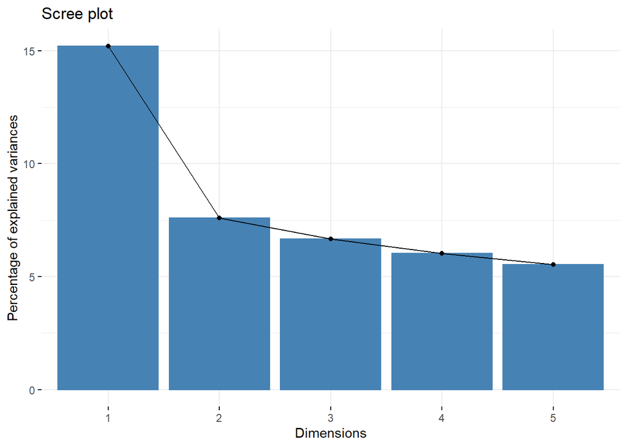

```r
fviz_screeplot(res.famd)
```

# Exemple of modelisation with Axes

```r
# recuperate three first axes
x = as_tibble(get_famd_ind(res.famd)$coord)[1:3]
```

Bind the target with the individual scores

```r
df.glm = cbind(heart_data[14], x)
```

```r
m.logit = glm(target~., data = df.glm, family = binomial)
```

Let’s get train set and test set

```r
d = sort(sample(nrow(df.glm), nrow(df.glm) * 0.7))

appren <- df.glm[d, ]

test <- df.glm[-d, ]
```

final mode

```r
m.logit <- glm(target~., data = appren, family = binomial)
summary(m.logit)
```

```
##
## Call:
## glm(formula = target ~ ., family = binomial, data = appren)
##
## Deviance Residuals:
##     Min       1Q   Median       3Q      Max
## -2.3175  -0.4771   0.2206   0.5461   2.7670
##
## Coefficients:
##             Estimate Std. Error z value Pr(>|z|)
## (Intercept)  0.04396    0.10840   0.405    0.685
## Dim.1       -1.23446    0.08716 -14.163  < 2e-16 ***
## Dim.2        0.46137    0.08536   5.405 6.49e-08 ***
## Dim.3        0.20122    0.08271   2.433    0.015 *
## ---
## Signif. codes:  0 '***' 0.001 '**' 0.01 '*' 0.05 '.' 0.1 ' ' 1
##
## (Dispersion parameter for binomial family taken to be 1)
##
##     Null deviance: 992.96  on 716  degrees of freedom
## Residual deviance: 546.46  on 713  degrees of freedom
## AIC: 554.46
##
## Number of Fisher Scoring iterations: 5
```

After obtaining a model, it is necessary to diagnose the regression in order to validate or not the model.

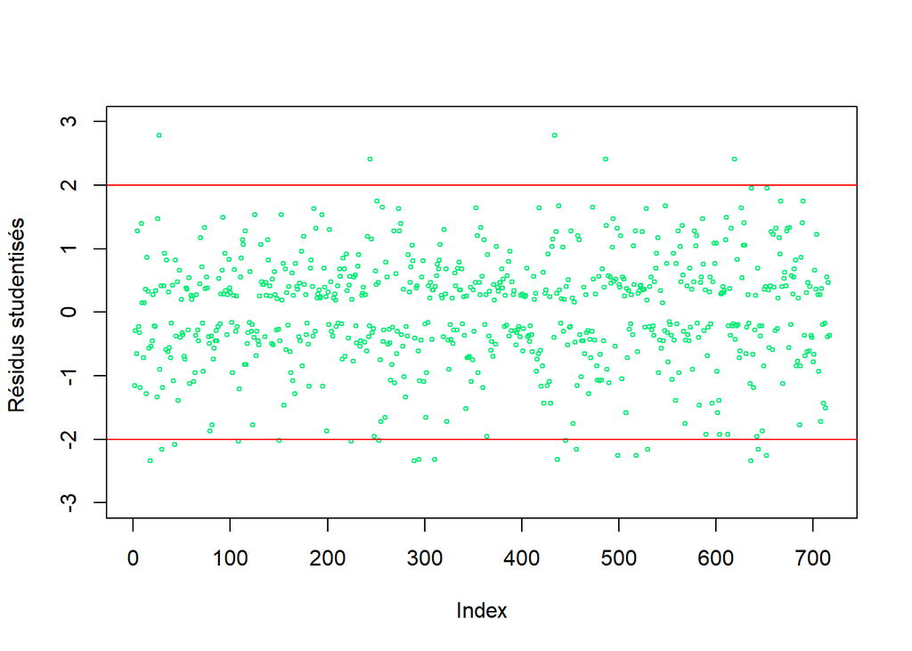

```r
par(mfrow = c(1, 1))
plot(rstudent(m.logit), type = "p", cex = 0.5, ylab = "Résidus studentisés ",
    col = "springgreen2", ylim = c(-3, 3))
abline(h = c(-2, 2), col = "red")
```

```r
(chi2 <- with(m.logit, null.deviance - deviance))
```

```
## [1] 446.4961
```

```r
(ddl <- with(m.logit, df.null - df.residual))
```

```
## [1] 3
```

```r
(pvalue <- pchisq(chi2, ddl, lower.tail = F))
```

```
## [1] 1.872455e-96
```

## We are now going to try to validate on the test sample that we have previously defined

Here are the steps we will follow to validate our model

On the training sample and on the test sample:

We calculate a confusion matrix: and therefore we measure an error rate the air is evaluated under the ROC curve

```r
appren.p <- cbind(appren, predict(m.logit, newdata = appren, type = "link",
    se = TRUE))
head(appren.p)
```

```
##   target      Dim.1      Dim.2      Dim.3         fit    se.fit residual.scale
## 1      0 -0.2029163 -1.0209037  0.5079003 -0.07436399 0.1451104              1
## 3      0  2.5565727 -1.0315848  1.9316291 -3.19928705 0.3020213              1
## 5      0  1.9181210  2.1889356 -0.7769859 -1.47032547 0.2617107              1
## 6      1  0.1179103  0.4230893 -1.6263020 -0.23363999 0.1776448              1
## 7      0  3.8213330  1.3205891  2.0018908 -3.66122877 0.3742308              1
## 8      0  2.1487247 -0.3602091 -0.9447778 -2.96484897 0.2492684              1
```

```r
appren.p <- within(appren.p, {
    PredictedProb <- plogis(fit)
    LL <- plogis(fit - (1.96 * se.fit))
    UL <- plogis(fit + (1.96 * se.fit))
})
tail(appren.p)
```

```
##      target     Dim.1      Dim.2       Dim.3        fit    se.fit
## 1018      0  2.831700 -1.3831414 -0.83126814 -4.2570603 0.3319046
## 1019      0 -1.222059 -1.9392214  0.27947581  0.7140815 0.2154980
## 1021      1 -1.561600 -0.4166821  0.02585137  1.7846456 0.1718362
## 1023      0  1.302375 -1.3609903 -1.92509081 -2.5790491 0.2813894
## 1024      1 -1.635673  0.6198536 -1.00543932  2.1467944 0.1994440
## 1025      0  1.272523 -2.1110946 -1.05094801 -2.7123773 0.2820767
##      residual.scale         UL          LL PredictedProb
## 1018              1 0.02642852 0.007336038    0.01396607
## 1019              1 0.75702867 0.572413591    0.67130240
## 1021              1 0.89297008 0.809666813    0.85626956
## 1023              1 0.11634304 0.041863649    0.07049902
## 1024              1 0.92674314 0.852693431    0.89536884
## 1025              1 0.10344617 0.036782831    0.06224694
```

```r
appren.p <- cbind(appren.p, pred.target = factor(ifelse(appren.p$PredictedProb >
    0.5, 1, 0)))
head(appren.p)
```

```
##   target      Dim.1      Dim.2      Dim.3         fit    se.fit residual.scale
## 1      0 -0.2029163 -1.0209037  0.5079003 -0.07436399 0.1451104              1
## 3      0  2.5565727 -1.0315848  1.9316291 -3.19928705 0.3020213              1
## 5      0  1.9181210  2.1889356 -0.7769859 -1.47032547 0.2617107              1
## 6      1  0.1179103  0.4230893 -1.6263020 -0.23363999 0.1776448              1
## 7      0  3.8213330  1.3205891  2.0018908 -3.66122877 0.3742308              1
## 8      0  2.1487247 -0.3602091 -0.9447778 -2.96484897 0.2492684              1
##           UL         LL PredictedProb pred.target
## 1 0.55232089 0.41125481    0.48141756           0
## 3 0.06866847 0.02206935    0.03919256           0
## 5 0.27740458 0.12096978    0.18689315           0
## 6 0.52860471 0.35851303    0.44185427           0
## 7 0.05079936 0.01219185    0.02505693           0
## 8 0.07753765 0.03066718    0.04903938           0
```

```r
(m.confusion <- as.matrix(table(appren.p$pred.target, appren.p$target)))
```

```
##
##       0   1
##   0 284  67
##   1  61 305
```

```r
m.confusion <- unclass(m.confusion)
# Taux d'erreur
Tx_err <- function(y, ypred) {
    mc <- table(y, ypred)
    error <- (mc[1, 2] + mc[2, 1])/sum(mc)
    print(error)
}
Tx_err(appren.p$pred.target, appren.p$target)
```

```
## [1] 0.1785216
```

```r
test.p <- cbind(test, predict(m.logit, newdata = test, type = "response", se = TRUE))
test.p <- cbind(test.p, pred.target <- factor(ifelse(test.p$fit > 0.5, 1, 0)))
(m.confusiontest <- as.matrix(table(test.p$pred.target, test.p$target)))
```

```
##
##       0   1
##   0 127  24
##   1  27 130
```

### calculation of the error rate on the test sample

```r
m.confusiontest <- unclass(m.confusiontest)

Tx_err(test.p$pred.target, test.p$target)
```

```
## [1] 0.1655844
```